# Optimal Treatment Analysis

## Outcome Variable

**Outcome Variable:** whz

## Predictor Variables

**Intervention Variable:** hdlvry

**Adjustment Set:**

- arm
- sex
- W_mage
- meducyrs
- feducyrs
- hhwealth_quart
- single
- W_nrooms
- brthmon
- W_parity
- impsan
- delta_W_mage
- delta_meducyrs
- delta_feducyrs
- delta_hhwealth_quart
- delta_single
- delta_W_nrooms
- delta_brthmon
- delta_W_parity
- delta_impsan

## Stratifying Variables

The analysis was stratified on these variable(s):

- agecat
- studyid
- country

## Data Summary

| agecat | studyid | country | hdlvry | n_cell | n |
| --- | --- | --- | --- | --- | --- |
| Birth | ki1000108-CMC-V-BCS-2002 | INDIA | 0 | 86 | 86 |
| Birth | ki1000108-CMC-V-BCS-2002 | INDIA | 1 | 0 | 86 |
| Birth | ki1000108-IRC | INDIA | 0 | 337 | 343 |
| Birth | ki1000108-IRC | INDIA | 1 | 6 | 343 |
| Birth | ki1000109-EE | PAKISTAN | 0 | 120 | 175 |
| Birth | ki1000109-EE | PAKISTAN | 1 | 55 | 175 |
| Birth | ki1000304b-SAS-CompFeed | INDIA | 0 | 108 | 957 |
| Birth | ki1000304b-SAS-CompFeed | INDIA | 1 | 849 | 957 |
| Birth | ki1017093b-PROVIDE | BANGLADESH | 0 | 387 | 532 |
| Birth | ki1017093b-PROVIDE | BANGLADESH | 1 | 145 | 532 |
| Birth | ki1017093c-NIH-Crypto | BANGLADESH | 0 | 548 | 707 |
| Birth | ki1017093c-NIH-Crypto | BANGLADESH | 1 | 159 | 707 |
| Birth | ki1113344-GMS-Nepal | NEPAL | 0 | 143 | 596 |
| Birth | ki1113344-GMS-Nepal | NEPAL | 1 | 453 | 596 |
| Birth | ki1135781-COHORTS | INDIA | 0 | 2763 | 4389 |
| Birth | ki1135781-COHORTS | INDIA | 1 | 1626 | 4389 |
| Birth | kiGH5241-JiVitA-3 | BANGLADESH | 0 | 27 | 292 |
| Birth | kiGH5241-JiVitA-3 | BANGLADESH | 1 | 265 | 292 |
| Birth | kiGH5241-JiVitA-4 | BANGLADESH | 0 | 500 | 2384 |
| Birth | kiGH5241-JiVitA-4 | BANGLADESH | 1 | 1884 | 2384 |
| 6 months | ki1000108-CMC-V-BCS-2002 | INDIA | 0 | 357 | 365 |
| 6 months | ki1000108-CMC-V-BCS-2002 | INDIA | 1 | 8 | 365 |
| 6 months | ki1000108-IRC | INDIA | 0 | 400 | 408 |
| 6 months | ki1000108-IRC | INDIA | 1 | 8 | 408 |
| 6 months | ki1000109-EE | PAKISTAN | 0 | 252 | 373 |
| 6 months | ki1000109-EE | PAKISTAN | 1 | 121 | 373 |
| 6 months | ki1000304b-SAS-CompFeed | INDIA | 0 | 147 | 1088 |
| 6 months | ki1000304b-SAS-CompFeed | INDIA | 1 | 941 | 1088 |
| 6 months | ki1000304b-SAS-FoodSuppl | INDIA | 0 | 76 | 380 |
| 6 months | ki1000304b-SAS-FoodSuppl | INDIA | 1 | 304 | 380 |
| 6 months | ki1017093b-PROVIDE | BANGLADESH | 0 | 450 | 603 |
| 6 months | ki1017093b-PROVIDE | BANGLADESH | 1 | 153 | 603 |
| 6 months | ki1017093c-NIH-Crypto | BANGLADESH | 0 | 554 | 715 |
| 6 months | ki1017093c-NIH-Crypto | BANGLADESH | 1 | 161 | 715 |
| 6 months | ki1066203-TanzaniaChild2 | TANZANIA, UNITED REPUBLIC OF | 0 | 1888 | 1920 |
| 6 months | ki1066203-TanzaniaChild2 | TANZANIA, UNITED REPUBLIC OF | 1 | 32 | 1920 |
| 6 months | ki1113344-GMS-Nepal | NEPAL | 0 | 129 | 528 |
| 6 months | ki1113344-GMS-Nepal | NEPAL | 1 | 399 | 528 |
| 6 months | ki1135781-COHORTS | INDIA | 0 | 2896 | 4694 |
| 6 months | ki1135781-COHORTS | INDIA | 1 | 1798 | 4694 |
| 6 months | kiGH5241-JiVitA-3 | BANGLADESH | 0 | 39 | 334 |
| 6 months | kiGH5241-JiVitA-3 | BANGLADESH | 1 | 295 | 334 |
| 6 months | kiGH5241-JiVitA-4 | BANGLADESH | 0 | 1082 | 4042 |
| 6 months | kiGH5241-JiVitA-4 | BANGLADESH | 1 | 2960 | 4042 |
| 24 months | ki1000108-CMC-V-BCS-2002 | INDIA | 0 | 361 | 369 |
| 24 months | ki1000108-CMC-V-BCS-2002 | INDIA | 1 | 8 | 369 |
| 24 months | ki1000108-IRC | INDIA | 0 | 401 | 409 |
| 24 months | ki1000108-IRC | INDIA | 1 | 8 | 409 |
| 24 months | ki1000109-EE | PAKISTAN | 0 | 112 | 167 |
| 24 months | ki1000109-EE | PAKISTAN | 1 | 55 | 167 |
| 24 months | ki1017093b-PROVIDE | BANGLADESH | 0 | 433 | 579 |
| 24 months | ki1017093b-PROVIDE | BANGLADESH | 1 | 146 | 579 |
| 24 months | ki1017093c-NIH-Crypto | BANGLADESH | 0 | 391 | 514 |
| 24 months | ki1017093c-NIH-Crypto | BANGLADESH | 1 | 123 | 514 |
| 24 months | ki1066203-TanzaniaChild2 | TANZANIA, UNITED REPUBLIC OF | 0 | 6 | 6 |
| 24 months | ki1066203-TanzaniaChild2 | TANZANIA, UNITED REPUBLIC OF | 1 | 0 | 6 |
| 24 months | ki1113344-GMS-Nepal | NEPAL | 0 | 118 | 455 |
| 24 months | ki1113344-GMS-Nepal | NEPAL | 1 | 337 | 455 |
| 24 months | ki1135781-COHORTS | INDIA | 0 | 2214 | 3533 |
| 24 months | ki1135781-COHORTS | INDIA | 1 | 1319 | 3533 |
| 24 months | kiGH5241-JiVitA-3 | BANGLADESH | 0 | 34 | 289 |
| 24 months | kiGH5241-JiVitA-3 | BANGLADESH | 1 | 255 | 289 |
| 24 months | kiGH5241-JiVitA-4 | BANGLADESH | 0 | 1032 | 3993 |
| 24 months | kiGH5241-JiVitA-4 | BANGLADESH | 1 | 2961 | 3993 |

The following strata were considered:

- agecat: 24 months, studyid: ki1000108-CMC-V-BCS-2002, country: INDIA
- agecat: 24 months, studyid: ki1000108-IRC, country: INDIA
- agecat: 24 months, studyid: ki1000109-EE, country: PAKISTAN
- agecat: 24 months, studyid: ki1017093b-PROVIDE, country: BANGLADESH
- agecat: 24 months, studyid: ki1017093c-NIH-Crypto, country: BANGLADESH
- agecat: 24 months, studyid: ki1066203-TanzaniaChild2, country: TANZANIA, UNITED REPUBLIC OF
- agecat: 24 months, studyid: ki1113344-GMS-Nepal, country: NEPAL
- agecat: 24 months, studyid: ki1135781-COHORTS, country: INDIA
- agecat: 24 months, studyid: kiGH5241-JiVitA-3, country: BANGLADESH
- agecat: 24 months, studyid: kiGH5241-JiVitA-4, country: BANGLADESH
- agecat: 6 months, studyid: ki1000108-CMC-V-BCS-2002, country: INDIA
- agecat: 6 months, studyid: ki1000108-IRC, country: INDIA
- agecat: 6 months, studyid: ki1000109-EE, country: PAKISTAN
- agecat: 6 months, studyid: ki1000304b-SAS-CompFeed, country: INDIA
- agecat: 6 months, studyid: ki1000304b-SAS-FoodSuppl, country: INDIA
- agecat: 6 months, studyid: ki1017093b-PROVIDE, country: BANGLADESH
- agecat: 6 months, studyid: ki1017093c-NIH-Crypto, country: BANGLADESH
- agecat: 6 months, studyid: ki1066203-TanzaniaChild2, country: TANZANIA, UNITED REPUBLIC OF
- agecat: 6 months, studyid: ki1113344-GMS-Nepal, country: NEPAL
- agecat: 6 months, studyid: ki1135781-COHORTS, country: INDIA
- agecat: 6 months, studyid: kiGH5241-JiVitA-3, country: BANGLADESH
- agecat: 6 months, studyid: kiGH5241-JiVitA-4, country: BANGLADESH
- agecat: Birth, studyid: ki1000108-CMC-V-BCS-2002, country: INDIA
- agecat: Birth, studyid: ki1000108-IRC, country: INDIA
- agecat: Birth, studyid: ki1000109-EE, country: PAKISTAN
- agecat: Birth, studyid: ki1000304b-SAS-CompFeed, country: INDIA
- agecat: Birth, studyid: ki1017093b-PROVIDE, country: BANGLADESH
- agecat: Birth, studyid: ki1017093c-NIH-Crypto, country: BANGLADESH
- agecat: Birth, studyid: ki1113344-GMS-Nepal, country: NEPAL
- agecat: Birth, studyid: ki1135781-COHORTS, country: INDIA
- agecat: Birth, studyid: kiGH5241-JiVitA-3, country: BANGLADESH
- agecat: Birth, studyid: kiGH5241-JiVitA-4, country: BANGLADESH

### Dropped Strata

Some strata were dropped due to rare outcomes:

- agecat: Birth, studyid: ki1000108-CMC-V-BCS-2002, country: INDIA
- agecat: 24 months, studyid: ki1066203-TanzaniaChild2, country: TANZANIA, UNITED REPUBLIC OF

## Methods Detail

We’re interested in the causal parameters $E[Y_a]$ for all values of $a \in \mathcal{A}$. These parameters represent the mean outcome if, possibly contrary to fact, we intervened to set all units to have $A=a$. Under the randomization and positivity assumptions, these are identified by the statistical parameters $\psi_a=E_W[E_{Y|A,W}(Y|A=a,W)]$. In addition, we’re interested in the mean of $Y$, $E[Y]$ under no intervention (the observed mean). We will estimate these parameters by using SuperLearner to fit the relevant likelihood factors – $E_{Y|A,W}(Y|A=a,W)$ and $p(A=a|W)$, and then updating our likelihood fit using a joint TMLE.

For unadjusted analyses ($W=\{\}$), initial likelihoods were estimated using Lrnr_glm to estimate the simple $E(Y|A)$ and Lrnr_mean to estimate $p(A)$. For adjusted analyses, a small library containing Lrnr_glmnet, Lrnr_xgboost, and Lrnr_mean was used.

Having estimated these parameters, we will then use the delta method to estimate relative risks and attributable risks relative to a prespecified baseline level of $A$.

# Results Detail

## Results Plots

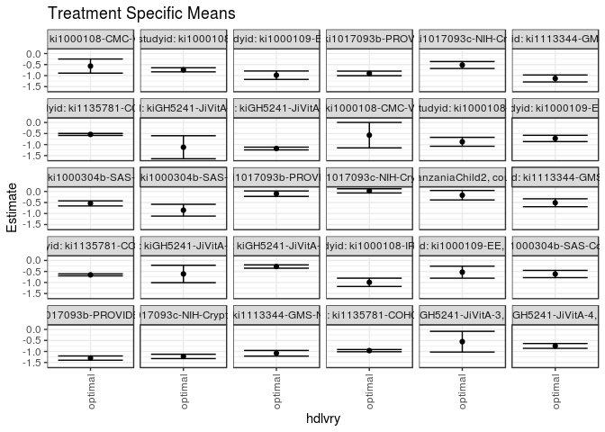

## Results Table

### Parameter: TSM

| agecat | studyid | country | intervention_level | baseline_level | estimate | ci_lower | ci_upper |
| --- | --- | --- | --- | --- | --- | --- | --- |
| Birth | ki1000108-IRC | INDIA | optimal | observed | -0.9921082 | -1.1807109 | -0.8035055 |
| Birth | ki1000109-EE | PAKISTAN | optimal | observed | -0.5326315 | -0.8056248 | -0.2596382 |
| Birth | ki1000304b-SAS-CompFeed | INDIA | optimal | observed | -0.6156644 | -0.7805488 | -0.4507799 |
| Birth | ki1017093b-PROVIDE | BANGLADESH | optimal | observed | -1.3004215 | -1.3964133 | -1.2044297 |
| Birth | ki1017093c-NIH-Crypto | BANGLADESH | optimal | observed | -1.2244849 | -1.3230875 | -1.1258822 |
| Birth | ki1113344-GMS-Nepal | NEPAL | optimal | observed | -1.0827678 | -1.2108185 | -0.9547171 |
| Birth | ki1135781-COHORTS | INDIA | optimal | observed | -0.9622272 | -1.0126378 | -0.9118166 |
| Birth | kiGH5241-JiVitA-3 | BANGLADESH | optimal | observed | -0.5565345 | -1.0274083 | -0.0856607 |
| Birth | kiGH5241-JiVitA-4 | BANGLADESH | optimal | observed | -0.7491056 | -0.8585895 | -0.6396217 |
| 6 months | ki1000108-CMC-V-BCS-2002 | INDIA | optimal | observed | -0.5742113 | -1.1522443 | 0.0038217 |
| 6 months | ki1000108-IRC | INDIA | optimal | observed | -0.8744759 | -1.0764213 | -0.6725305 |
| 6 months | ki1000109-EE | PAKISTAN | optimal | observed | -0.7232425 | -0.8661072 | -0.5803778 |
| 6 months | ki1000304b-SAS-CompFeed | INDIA | optimal | observed | -0.5405186 | -0.6567042 | -0.4243331 |
| 6 months | ki1000304b-SAS-FoodSuppl | INDIA | optimal | observed | -0.8491582 | -1.1168254 | -0.5814911 |
| 6 months | ki1017093b-PROVIDE | BANGLADESH | optimal | observed | -0.0989871 | -0.2216158 | 0.0236417 |
| 6 months | ki1017093c-NIH-Crypto | BANGLADESH | optimal | observed | 0.0276276 | -0.0686212 | 0.1238765 |
| 6 months | ki1066203-TanzaniaChild2 | TANZANIA, UNITED REPUBLIC OF | optimal | observed | -0.1695735 | -0.3846938 | 0.0455467 |
| 6 months | ki1113344-GMS-Nepal | NEPAL | optimal | observed | -0.5119199 | -0.6922835 | -0.3315563 |
| 6 months | ki1135781-COHORTS | INDIA | optimal | observed | -0.6534853 | -0.6976334 | -0.6093372 |
| 6 months | kiGH5241-JiVitA-3 | BANGLADESH | optimal | observed | -0.6125832 | -1.0072497 | -0.2179167 |
| 6 months | kiGH5241-JiVitA-4 | BANGLADESH | optimal | observed | -0.2758688 | -0.3510709 | -0.2006667 |
| 24 months | ki1000108-CMC-V-BCS-2002 | INDIA | optimal | observed | -0.5686933 | -0.8893757 | -0.2480109 |
| 24 months | ki1000108-IRC | INDIA | optimal | observed | -0.7384584 | -0.8312901 | -0.6456267 |
| 24 months | ki1000109-EE | PAKISTAN | optimal | observed | -0.9827162 | -1.1737863 | -0.7916462 |
| 24 months | ki1017093b-PROVIDE | BANGLADESH | optimal | observed | -0.9017142 | -1.0059116 | -0.7975167 |
| 24 months | ki1017093c-NIH-Crypto | BANGLADESH | optimal | observed | -0.5205971 | -0.6773437 | -0.3638505 |
| 24 months | ki1113344-GMS-Nepal | NEPAL | optimal | observed | -1.1296712 | -1.2871771 | -0.9721653 |
| 24 months | ki1135781-COHORTS | INDIA | optimal | observed | -0.5402508 | -0.5849939 | -0.4955077 |
| 24 months | kiGH5241-JiVitA-3 | BANGLADESH | optimal | observed | -1.1219822 | -1.6447711 | -0.5991933 |
| 24 months | kiGH5241-JiVitA-4 | BANGLADESH | optimal | observed | -1.1796303 | -1.2422418 | -1.1170188 |

### Parameter: E(Y)

| agecat | studyid | country | intervention_level | baseline_level | estimate | ci_lower | ci_upper |
| --- | --- | --- | --- | --- | --- | --- | --- |
| Birth | ki1000108-IRC | INDIA | observed | observed | -1.0105831 | -1.1973019 | -0.8238643 |
| Birth | ki1000109-EE | PAKISTAN | observed | observed | -0.3410000 | -0.5302198 | -0.1517802 |
| Birth | ki1000304b-SAS-CompFeed | INDIA | observed | observed | -0.6570846 | -0.8496671 | -0.4645022 |
| Birth | ki1017093b-PROVIDE | BANGLADESH | observed | observed | -1.2984586 | -1.3752758 | -1.2216415 |
| Birth | ki1017093c-NIH-Crypto | BANGLADESH | observed | observed | -1.2441513 | -1.3281130 | -1.1601897 |
| Birth | ki1113344-GMS-Nepal | NEPAL | observed | observed | -1.1277349 | -1.2174865 | -1.0379833 |
| Birth | ki1135781-COHORTS | INDIA | observed | observed | -0.9755867 | -1.0106993 | -0.9404741 |
| Birth | kiGH5241-JiVitA-3 | BANGLADESH | observed | observed | -0.8532192 | -0.9644938 | -0.7419446 |
| Birth | kiGH5241-JiVitA-4 | BANGLADESH | observed | observed | -0.6907341 | -0.7437042 | -0.6377640 |
| 6 months | ki1000108-CMC-V-BCS-2002 | INDIA | observed | observed | -0.5045068 | -0.6566169 | -0.3523968 |
| 6 months | ki1000108-IRC | INDIA | observed | observed | -0.5989297 | -0.7344491 | -0.4634104 |
| 6 months | ki1000109-EE | PAKISTAN | observed | observed | -0.7695800 | -0.8839306 | -0.6552294 |
| 6 months | ki1000304b-SAS-CompFeed | INDIA | observed | observed | -0.6734421 | -0.8121314 | -0.5347528 |
| 6 months | ki1000304b-SAS-FoodSuppl | INDIA | observed | observed | -1.0121579 | -1.1280429 | -0.8962729 |
| 6 months | ki1017093b-PROVIDE | BANGLADESH | observed | observed | -0.1990907 | -0.2817968 | -0.1163845 |
| 6 months | ki1017093c-NIH-Crypto | BANGLADESH | observed | observed | 0.0297622 | -0.0491685 | 0.1086930 |
| 6 months | ki1066203-TanzaniaChild2 | TANZANIA, UNITED REPUBLIC OF | observed | observed | 0.0688763 | 0.0147308 | 0.1230218 |
| 6 months | ki1113344-GMS-Nepal | NEPAL | observed | observed | -0.5992551 | -0.6878945 | -0.5106156 |
| 6 months | ki1135781-COHORTS | INDIA | observed | observed | -0.7160077 | -0.7492815 | -0.6827338 |
| 6 months | kiGH5241-JiVitA-3 | BANGLADESH | observed | observed | -0.6044910 | -0.7122040 | -0.4967781 |
| 6 months | kiGH5241-JiVitA-4 | BANGLADESH | observed | observed | -0.3760651 | -0.4191017 | -0.3330285 |
| 24 months | ki1000108-CMC-V-BCS-2002 | INDIA | observed | observed | -0.5436992 | -0.6434110 | -0.4439874 |
| 24 months | ki1000108-IRC | INDIA | observed | observed | -0.7458150 | -0.8368180 | -0.6548120 |
| 24 months | ki1000109-EE | PAKISTAN | observed | observed | -1.0103892 | -1.1580613 | -0.8627171 |
| 24 months | ki1017093b-PROVIDE | BANGLADESH | observed | observed | -0.8928670 | -0.9755153 | -0.8102187 |
| 24 months | ki1017093c-NIH-Crypto | BANGLADESH | observed | observed | -0.6103502 | -0.7050157 | -0.5156847 |
| 24 months | ki1113344-GMS-Nepal | NEPAL | observed | observed | -1.1238388 | -1.2161263 | -1.0315513 |
| 24 months | ki1135781-COHORTS | INDIA | observed | observed | -0.6520577 | -0.6860033 | -0.6181122 |
| 24 months | kiGH5241-JiVitA-3 | BANGLADESH | observed | observed | -1.2989273 | -1.4377964 | -1.1600583 |
| 24 months | kiGH5241-JiVitA-4 | BANGLADESH | observed | observed | -1.2421463 | -1.2763113 | -1.2079812 |

### Parameter: PAR

| agecat | studyid | country | intervention_level | baseline_level | estimate | ci_lower | ci_upper |
| --- | --- | --- | --- | --- | --- | --- | --- |
| Birth | ki1000108-IRC | INDIA | optimal | observed | -0.0184749 | -0.0511544 | 0.0142046 |
| Birth | ki1000109-EE | PAKISTAN | optimal | observed | 0.1916315 | 0.0048230 | 0.3784400 |
| Birth | ki1000304b-SAS-CompFeed | INDIA | optimal | observed | -0.0414203 | -0.1343226 | 0.0514821 |
| Birth | ki1017093b-PROVIDE | BANGLADESH | optimal | observed | 0.0019628 | -0.0621984 | 0.0661240 |
| Birth | ki1017093c-NIH-Crypto | BANGLADESH | optimal | observed | -0.0196665 | -0.0731178 | 0.0337849 |
| Birth | ki1113344-GMS-Nepal | NEPAL | optimal | observed | -0.0449671 | -0.1362270 | 0.0462928 |
| Birth | ki1135781-COHORTS | INDIA | optimal | observed | -0.0133595 | -0.0501459 | 0.0234269 |
| Birth | kiGH5241-JiVitA-3 | BANGLADESH | optimal | observed | -0.2966847 | -0.7769955 | 0.1836262 |
| Birth | kiGH5241-JiVitA-4 | BANGLADESH | optimal | observed | 0.0583715 | -0.0258807 | 0.1426238 |
| 6 months | ki1000108-CMC-V-BCS-2002 | INDIA | optimal | observed | 0.0697045 | -0.5097929 | 0.6492018 |
| 6 months | ki1000108-IRC | INDIA | optimal | observed | 0.2755462 | 0.1354733 | 0.4156190 |
| 6 months | ki1000109-EE | PAKISTAN | optimal | observed | -0.0463375 | -0.1259426 | 0.0332677 |
| 6 months | ki1000304b-SAS-CompFeed | INDIA | optimal | observed | -0.1329235 | -0.2908847 | 0.0250378 |
| 6 months | ki1000304b-SAS-FoodSuppl | INDIA | optimal | observed | -0.1629997 | -0.4092133 | 0.0832140 |
| 6 months | ki1017093b-PROVIDE | BANGLADESH | optimal | observed | -0.1001036 | -0.1963913 | -0.0038159 |
| 6 months | ki1017093c-NIH-Crypto | BANGLADESH | optimal | observed | 0.0021346 | -0.0551718 | 0.0594410 |
| 6 months | ki1066203-TanzaniaChild2 | TANZANIA, UNITED REPUBLIC OF | optimal | observed | 0.2384498 | 0.0260852 | 0.4508144 |
| 6 months | ki1113344-GMS-Nepal | NEPAL | optimal | observed | -0.0873351 | -0.2431457 | 0.0684755 |
| 6 months | ki1135781-COHORTS | INDIA | optimal | observed | -0.0625224 | -0.0932812 | -0.0317635 |
| 6 months | kiGH5241-JiVitA-3 | BANGLADESH | optimal | observed | 0.0080922 | -0.3573358 | 0.3735201 |
| 6 months | kiGH5241-JiVitA-4 | BANGLADESH | optimal | observed | -0.1001963 | -0.1660969 | -0.0342957 |
| 24 months | ki1000108-CMC-V-BCS-2002 | INDIA | optimal | observed | 0.0249941 | -0.3003200 | 0.3503083 |
| 24 months | ki1000108-IRC | INDIA | optimal | observed | -0.0073566 | -0.0171299 | 0.0024167 |
| 24 months | ki1000109-EE | PAKISTAN | optimal | observed | -0.0276730 | -0.1242414 | 0.0688954 |
| 24 months | ki1017093b-PROVIDE | BANGLADESH | optimal | observed | 0.0088471 | -0.0571099 | 0.0748042 |
| 24 months | ki1017093c-NIH-Crypto | BANGLADESH | optimal | observed | -0.0897531 | -0.2044673 | 0.0249611 |
| 24 months | ki1113344-GMS-Nepal | NEPAL | optimal | observed | 0.0058323 | -0.1259582 | 0.1376229 |
| 24 months | ki1135781-COHORTS | INDIA | optimal | observed | -0.1118069 | -0.1419006 | -0.0817133 |
| 24 months | kiGH5241-JiVitA-3 | BANGLADESH | optimal | observed | -0.1769451 | -0.6392785 | 0.2853883 |
| 24 months | kiGH5241-JiVitA-4 | BANGLADESH | optimal | observed | -0.0625159 | -0.1178282 | -0.0072037 |